# Mixed Effects Analysis

*NOTE: Data is imported from all_participants.csv*

#### Mixed Designs Analysis

The experimental design consists of 1 within-subjects factor (graph) with two levels (linear, triangular), and two between-subjects factors: scaffold condition (5 levels: no scaffold, ‘what’ text, ‘how’ text, static image, interactive image) and task order (linear-first, triangular-first).

> TIME
1. EXPLORE THE DATA

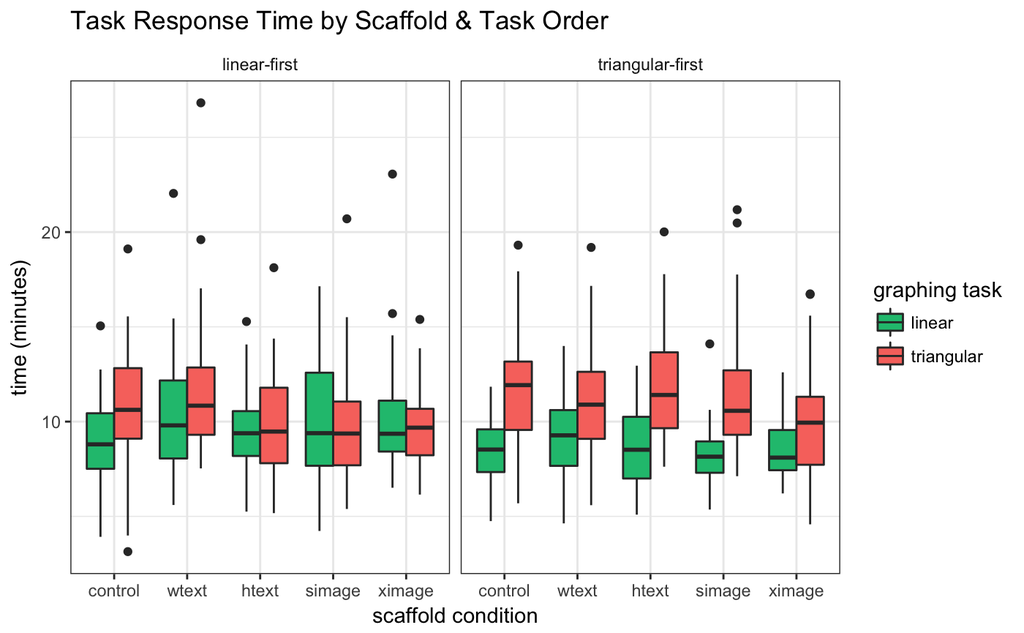

3. Construct contrasts for TIME &
4. Compute main model ANOVA

```
Converting "subject" to factor for ANOVA.Data is unbalanced (unequal N per group). Make sure you specified a well-considered value for the type argument to ezANOVA().
```

|  | Effect | DFn | DFd | SSn | SSd | F | p | p<.05 | ges |
| --- | --- | --- | --- | --- | --- | --- | --- | --- | --- |
| 1 | (Intercept) | 1 | 297 | 6.161855e+04 | 3628.982 | 5.042932e+03 | 2.201990e-188 | * | 9.280799e-01 |
| 2 | condition | 4 | 297 | 5.635493e+01 | 3628.982 | 1.153038e+00 | 3.317695e-01 |  | 1.166433e-02 |
| 3 | order | 1 | 297 | 4.122452e-01 | 3628.982 | 3.373861e-02 | 8.543893e-01 |  | 8.632596e-05 |
| 4 | lm_scenarios | 1 | 297 | 3.202562e+01 | 3628.982 | 2.621013e+00 | 1.065185e-01 |  | 6.662201e-03 |
| 9 | variable | 1 | 297 | 4.270689e+02 | 1146.054 | 1.106749e+02 | 3.290208e-22 | * | 8.209539e-02 |
| 5 | condition:order | 4 | 297 | 3.495670e+01 | 3628.982 | 7.152240e-01 | 5.820739e-01 |  | 7.267516e-03 |
| 6 | condition:lm_scenarios | 4 | 297 | 8.290158e+01 | 3628.982 | 1.696190e+00 | 1.508091e-01 |  | 1.706518e-02 |
| 7 | order:lm_scenarios | 1 | 297 | 1.786641e+01 | 3628.982 | 1.462207e+00 | 2.275410e-01 |  | 3.727680e-03 |
| 10 | condition:variable | 4 | 297 | 5.374119e+01 | 1146.054 | 3.481757e+00 | 8.478153e-03 | * | 1.112936e-02 |
| 11 | order:variable | 1 | 297 | 1.705570e+02 | 1146.054 | 4.419985e+01 | 1.419857e-10 | * | 3.448666e-02 |

[output cut: 6 more lines]

```
      Length Class      Mode
ANOVA 9      data.frame list
```

```r
#contrasts(l_times$variable)
#contrasts(l_times$condition)
#contrasts(l_times$lm_scenarios)
##contrasts(l_times$order)
```

> SCORE
1. EXPLORE THE DATA

[figure not shown]

4. Compute main model ANOVA

```
Converting "subject" to factor for ANOVA.Data is unbalanced (unequal N per group). Make sure you specified a well-considered value for the type argument to ezANOVA().
```

|  | Effect | DFn | DFd | SSn | SSd | F | p | p<.05 | ges |
| --- | --- | --- | --- | --- | --- | --- | --- | --- | --- |
| 1 | (Intercept) | 1 | 297 | 6.047743e+04 | 4314.936 | 4.162703e+03 | 9.171921e-177 | * | 0.9047069286 |
| 2 | condition | 4 | 297 | 2.504594e+02 | 4314.936 | 4.309823e+00 | 2.100960e-03 | * | 0.0378305107 |
| 3 | order | 1 | 297 | 1.095400e+01 | 4314.936 | 7.539710e-01 | 3.859230e-01 |  | 0.0017166417 |
| 4 | lm_scenarios | 1 | 297 | 3.238350e+02 | 4314.936 | 2.228978e+01 | 3.618430e-06 | * | 0.0483773143 |
| 9 | variable | 1 | 297 | 6.758264e+02 | 2055.171 | 9.766604e+01 | 4.249544e-20 | * | 0.0959172187 |
| 5 | condition:order | 4 | 297 | 4.024701e+01 | 4314.936 | 6.925573e-01 | 5.976030e-01 |  | 0.0062784375 |
| 6 | condition:lm_scenarios | 4 | 297 | 7.563630e+01 | 4314.936 | 1.301524e+00 | 2.694854e-01 |  | 0.0117343006 |
| 7 | order:lm_scenarios | 1 | 297 | 5.784207e-01 | 4314.936 | 3.981309e-02 | 8.419830e-01 |  | 0.0000907941 |
| 10 | condition:variable | 4 | 297 | 2.765678e+02 | 2055.171 | 9.991947e+00 | 1.340564e-07 | * | 0.0416099521 |
| 11 | order:variable | 1 | 297 | 2.319047e+01 | 2055.171 | 3.351335e+00 | 6.815241e-02 |  | 0.0036273087 |

[output cut: 6 more lines]

```
      Length Class      Mode
ANOVA 9      data.frame list
```

MIXED EFFECTS ANOVA ON SCORE Main effect of Scaffold F(4,297) = 4.31, p < .01 Main effect of Scenario F(1,297) = 22.29, p < .001 Main effect of Graph F(1,297) = 97.67, p < .001 Interaction of Scaffold and Graph F(4,297) = 9.99, p <.001 Interaction of Graph and Scenario F(1,297) = 34.80, p <.001

> DRAWING